# Assignment 3

Alessandro Giulivo, Francesca Rinaldi, Martina Monciotti

11/15/2021

```r
library(ggplot2)
library(ggfortify)
library(factoextra)
library(Rtsne)
library(dplyr)
```

Question 1

```r
#Read data
setwd("C:/Users/aless/Desktop/Bioinformatics/Erasmus BCN/Data Visualisation/homeassignment")
P3<- read.delim("P3.tsv.gz", row.names=1)
P4<- read.delim("P4.tsv.gz", row.names=1)
P5<- read.delim("P5.tsv.gz", row.names=1)

#Check data
head(P3, 5)
```

```
##                    P2769_N701.S502 P2769_N701.S503 P2769_N701.S505
## ENSG00000000003.14               0               0               0
## ENSG00000000005.5                0               0               0
## ENSG00000000419.12              39              68              16
## ENSG00000000457.13               0               8              17
## ENSG00000000460.16               0              46               4
##                    P2769_N701.S506 P2769_N701.S507 P2769_N701.S508
## ENSG00000000003.14               0               0               0
## ENSG00000000005.5                0               0               0
## ENSG00000000419.12               0               0               0
## ENSG00000000457.13               0               0               0
## ENSG00000000460.16               0               0               0
##                    P2769_N701.S510 P2769_N701.S511 P2769_N702.S502
## ENSG00000000003.14               0               0               0
## ENSG00000000005.5                0               0               0
## ENSG00000000419.12              23               2              24
## ENSG00000000457.13               0               0               0
## ENSG00000000460.16               0              11               7
##                    P2769_N702.S503 P2769_N702.S505 P2769_N702.S506
## ENSG00000000003.14               0               0               0
## ENSG00000000005.5                0               0               0
## ENSG00000000419.12              62              76               0
## ENSG00000000457.13               0               0               0
## ENSG00000000460.16               7               0               0
##                    P2769_N702.S507 P2769_N702.S508 P2769_N702.S510
## ENSG00000000003.14               0               0               0
## ENSG00000000005.5                0               0               0
## ENSG00000000419.12               0               0              39
## ENSG00000000457.13               0               0               0
## ENSG00000000460.16               0               0             170
##                    P2769_N702.S511 P2769_N703.S502 P2769_N703.S503
## ENSG00000000003.14               0               0            0.00
## ENSG00000000005.5                0               0            0.00
## ENSG00000000419.12              88              29           92.00
## ENSG00000000457.13               0               0           28.79
## ENSG00000000460.16               0               0          187.21
##                    P2769_N703.S505 P2769_N703.S506 P2769_N703.S507
## ENSG00000000003.14               0               0               0
## ENSG00000000005.5                0               0               0
## ENSG00000000419.12              39              69               0
```

[output cut: 137 more lines]

```
## ENSG00000000419.12              44             351              83
## ENSG00000000457.13              16               0               0
## ENSG00000000460.16               0               0             325
##                    P2769_N715.S505 P2769_N715.S506 P2769_N715.S507
## ENSG00000000003.14               0               0               0
## ENSG00000000005.5                0               0               0
## ENSG00000000419.12             292             110             110
## ENSG00000000457.13               0               0             136
## ENSG00000000460.16               0               0               2
##                    P2769_N715.S508 P2769_N715.S510 P2769_N715.S511
## ENSG00000000003.14               0               0               0
## ENSG00000000005.5                0               0               0
## ENSG00000000419.12               0              56               0
## ENSG00000000457.13               0               0               0
## ENSG00000000460.16               0               0              14
```

```r
head(P4, 5)
```

```
##                    P2770_N701.S513 P2770_N701.S515 P2770_N701.S516
## ENSG00000000003.14               0            0.00               0
## ENSG00000000005.5                0            0.00               0
## ENSG00000000419.12              49           79.00             144
## ENSG00000000457.13               0           68.42               0
## ENSG00000000460.16               0          127.58               0
##                    P2770_N701.S517 P2770_N701.S518 P2770_N701.S520
## ENSG00000000003.14               0               0               0
## ENSG00000000005.5                0               0               0
## ENSG00000000419.12              21               0              87
## ENSG00000000457.13               2               0               0
## ENSG00000000460.16              13               0               0
##                    P2770_N701.S521 P2770_N701.S522 P2770_N702.S513
## ENSG00000000003.14               0               0               0
## ENSG00000000005.5                0               0               0
## ENSG00000000419.12               0               0              75
## ENSG00000000457.13               0               0               0
## ENSG00000000460.16             202               0              82
##                    P2770_N702.S515 P2770_N702.S516 P2770_N702.S517
## ENSG00000000003.14            0.00            0.00               0
## ENSG00000000005.5             0.00            0.00               0
## ENSG00000000419.12          151.00           28.00              83
## ENSG00000000457.13           16.55           30.68               0
## ENSG00000000460.16          114.45           12.32               0
##                    P2770_N702.S518 P2770_N702.S520 P2770_N702.S521
## ENSG00000000003.14               0               0            0.00
## ENSG00000000005.5                0               0            0.00
## ENSG00000000419.12              33             185           95.00
## ENSG00000000457.13               0               0           11.64
## ENSG00000000460.16               0             105          208.36
##                    P2770_N702.S522 P2770_N703.S513 P2770_N703.S515
## ENSG00000000003.14               0               0               0
## ENSG00000000005.5                0               0               0
## ENSG00000000419.12               1              88              39
## ENSG00000000457.13               0               0               9
## ENSG00000000460.16               0              10              51
##                    P2770_N703.S516 P2770_N703.S517 P2770_N703.S518
## ENSG00000000003.14               0               0               0
## ENSG00000000005.5                0               0               0
## ENSG00000000419.12              84              60             137
```

[output cut: 137 more lines]

```
## ENSG00000000419.12           21.00              92              50
## ENSG00000000457.13           22.92              40              20
## ENSG00000000460.16          127.08               0               0
##                    P2770_N715.S516 P2770_N715.S517 P2770_N715.S518
## ENSG00000000003.14               0               0               0
## ENSG00000000005.5                0               0               0
## ENSG00000000419.12              61              43               3
## ENSG00000000457.13               0               0               0
## ENSG00000000460.16               0             118              92
##                    P2770_N715.S520 P2770_N715.S521 P2770_N715.S522
## ENSG00000000003.14               0               0               0
## ENSG00000000005.5                0               0               0
## ENSG00000000419.12              32              75              46
## ENSG00000000457.13               0               0               0
## ENSG00000000460.16               5               0               0
```

```r
head(P5, 5)
```

```
##                    P2771_N701.S502 P2771_N701.S503 P2771_N701.S505
## ENSG00000000003.14               0               0               0
## ENSG00000000005.5                0               0               0
## ENSG00000000419.12              41             127             113
## ENSG00000000457.13              60               2              16
## ENSG00000000460.16               0              59              48
##                    P2771_N701.S506 P2771_N701.S507 P2771_N701.S508
## ENSG00000000003.14               0               0               0
## ENSG00000000005.5                0               0               0
## ENSG00000000419.12              60               0             197
## ENSG00000000457.13               0               0               0
## ENSG00000000460.16               0               0               0
##                    P2771_N701.S510 P2771_N701.S511 P2771_N702.S502
## ENSG00000000003.14               0               0               0
## ENSG00000000005.5                0               0               0
## ENSG00000000419.12              14              35              84
## ENSG00000000457.13              55               0               9
## ENSG00000000460.16               0               0              65
##                    P2771_N702.S503 P2771_N702.S505 P2771_N702.S506
## ENSG00000000003.14            0.00            0.00               0
## ENSG00000000005.5             0.00            0.00               0
## ENSG00000000419.12          134.00           12.00              13
## ENSG00000000457.13           34.04           46.47               0
## ENSG00000000460.16           66.96           46.53               0
##                    P2771_N702.S507 P2771_N702.S508 P2771_N702.S510
## ENSG00000000003.14               0               0               0
## ENSG00000000005.5                0               0               0
## ENSG00000000419.12               0             151              57
## ENSG00000000457.13               0               0               0
## ENSG00000000460.16               0               0             102
##                    P2771_N702.S511 P2771_N703.S502 P2771_N703.S503
## ENSG00000000003.14               0               0            0.00
## ENSG00000000005.5                0               0            0.00
## ENSG00000000419.12               0              71           35.00
## ENSG00000000457.13               0               0           31.61
## ENSG00000000460.16               0               0           51.39
##                    P2771_N703.S505 P2771_N703.S506 P2771_N703.S507
## ENSG00000000003.14               0               0               0
## ENSG00000000005.5                0               0               0
## ENSG00000000419.12              24              11             129
```

[output cut: 137 more lines]

```
## ENSG00000000419.12              77               0              66
## ENSG00000000457.13               0               3               0
## ENSG00000000460.16               5              41               3
##                    P2771_N715.S505 P2771_N715.S506 P2771_N715.S507
## ENSG00000000003.14               0               0               0
## ENSG00000000005.5                0               0               0
## ENSG00000000419.12              32             101             235
## ENSG00000000457.13               0               0               0
## ENSG00000000460.16              57              15              51
##                    P2771_N715.S508 P2771_N715.S510 P2771_N715.S511
## ENSG00000000003.14               0               0               0
## ENSG00000000005.5                0               0               0
## ENSG00000000419.12              59              59              27
## ENSG00000000457.13               0               0               0
## ENSG00000000460.16               0               0               0
```

```r
#Alternatives
#P3<- read.table(gzfile("P3.tsv.gz", "rt"), header= TRUE)
#P4<- read.table(gzfile("P4.tsv.gz", "rt"), header= TRUE)
#P5<- read.table(gzfile("P5.tsv.gz", "rt"), header= TRUE)
```

Question 2

```r
treat<- read.delim("samplesheet.tsv", row.names=1)
#treat <- as.factor(readLines("samplesheet.tsv"))
#Alternatives
#treat<- read.table(("samplesheet.tsv", "rt"), header= TRUE))

table(treat)
```

```
## treat
## J-LatA2+DMSO  J-LatA2+PMA J-LatA2+SAHA  Jurkat+DMSO   Jurkat+PMA  Jurkat+SAHA
##           36           81           81           18           36           36
```

There are 2 kinds of cells (one infected with HIV and one with a latent virus), each one is treated with DMSO, SAHA and PMA. This creates 6 different combinations, the table above shows the number of cells in each condition.

Question 3

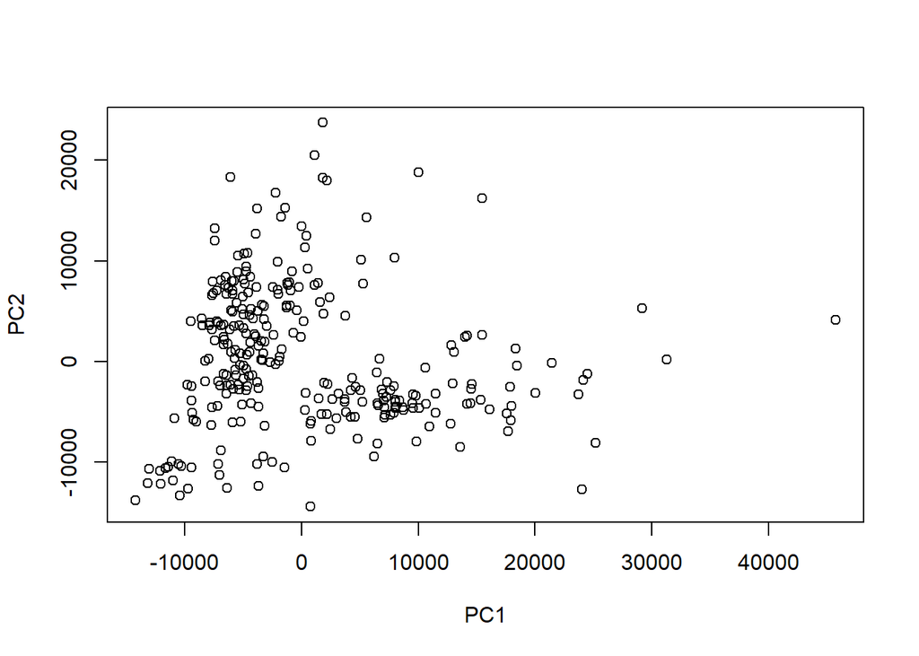

```r
X3 <- t(P3)
X4 <- t(P4)
X5 <- t(P5)

X1 = rbind(X3, X4, X5)

data <- data.frame(row.names= rownames(X1), experiment= as.factor(rep(c("A", "B", "C"), each=96)), treatment=treat)

colnames(data)<- c("experiment", "treatment")

#PCA
PCA = stats::prcomp(X1)
plot(PCA$x)
```

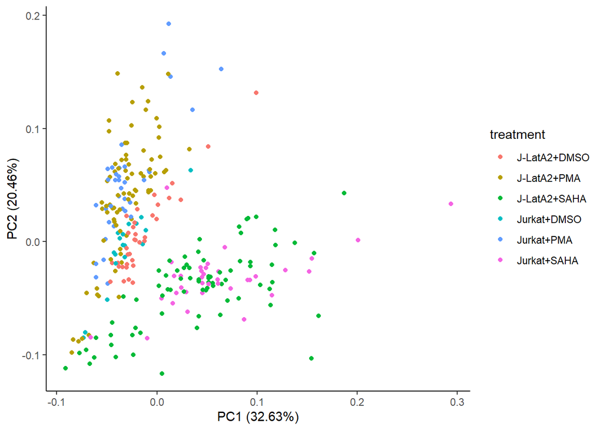

```r
#coloring by treatment
#using autoplot
ggplot2::autoplot(PCA, data = data, colour = "treatment") + theme_classic()
```

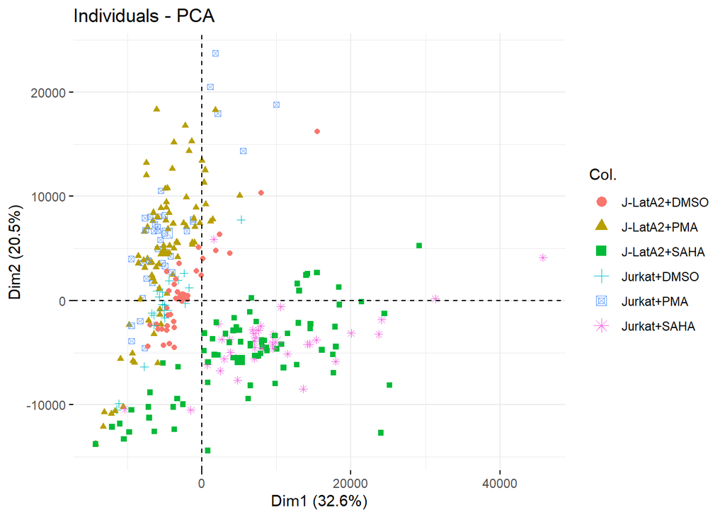

```r
#using factoextra
factoextra::fviz_pca_ind(PCA, geom = "point", col.ind = data$treatment)
```

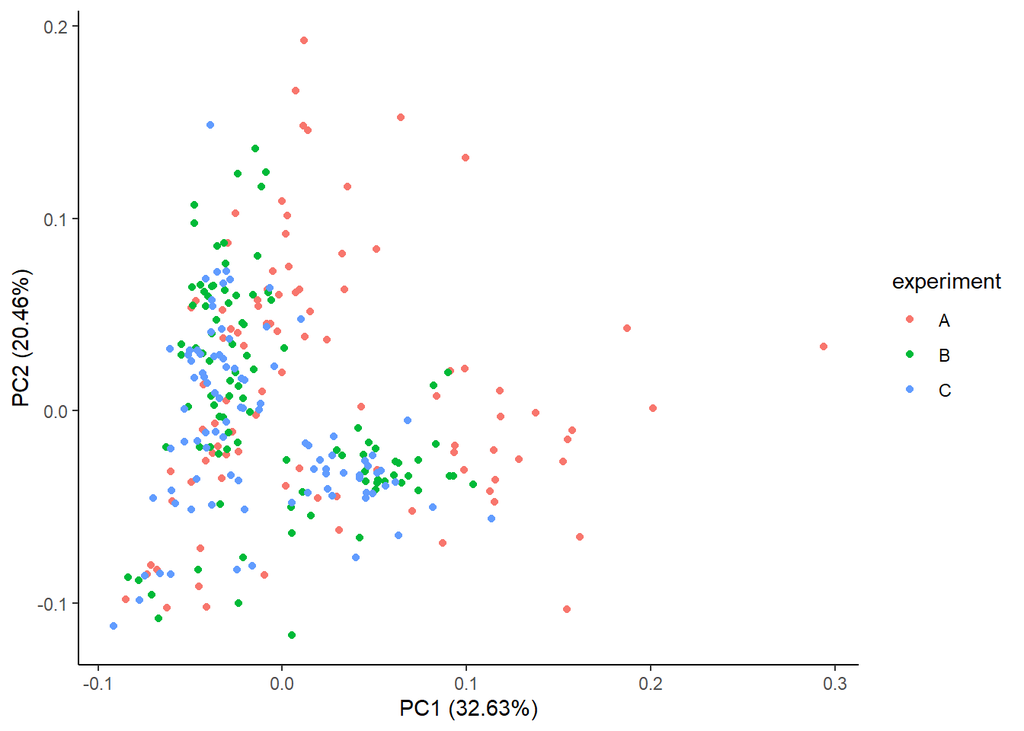

```r
#coloring by experiment
#using autoplot
ggplot2::autoplot(PCA, data = data, colour = "experiment") + theme_classic()
```

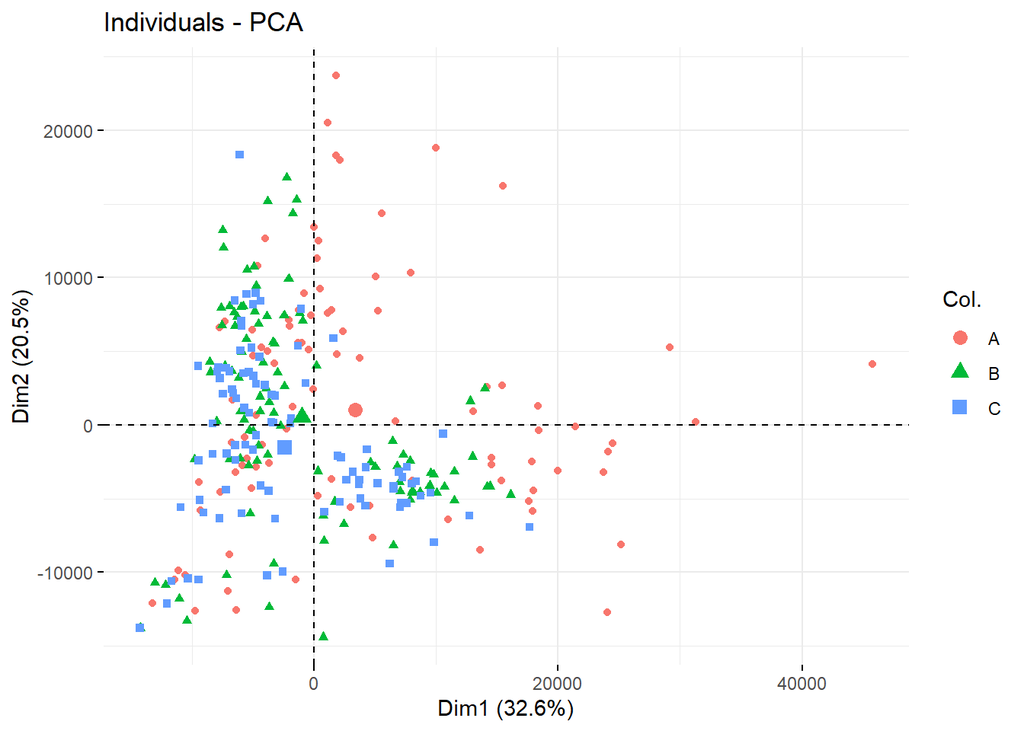

```r
#using factoextra
factoextra::fviz_pca_ind(PCA, geom = "point", col.ind = data$experiment)
```

```r
#creating scaled PCA
print(dim(X1))
```

```
## [1]   288 58780
```

```r
X1=X1[, colSums(X1)>0] ## tip: rowSums > 0
print(dim(X1))
```

```
## [1]   288 23104
```

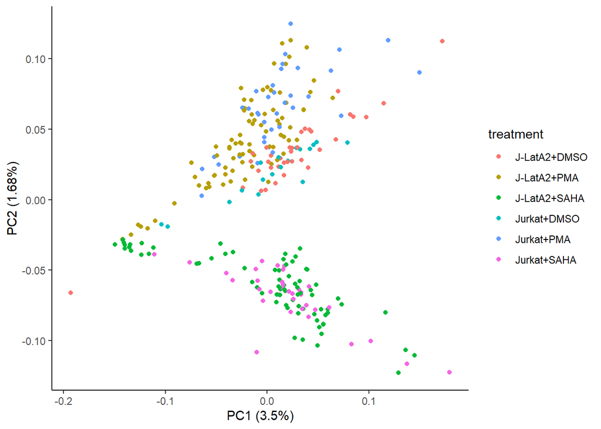

```r
pca_res_scaled <- stats::prcomp(X1, scale=TRUE)
#colored by treatment
ggplot2::autoplot(pca_res_scaled, data = data, colour = "treatment") + theme_classic()
```

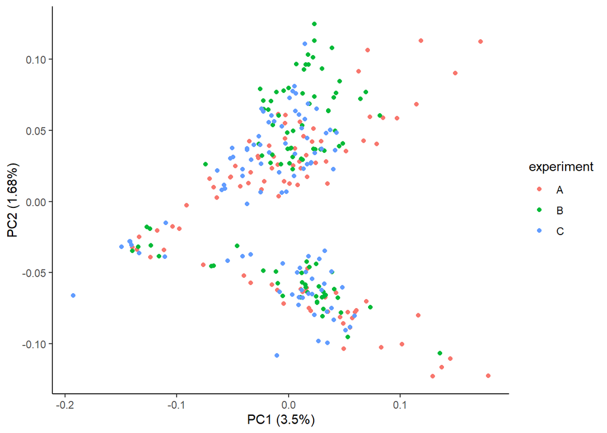

```r
#colored by experiment
ggplot2::autoplot(pca_res_scaled, data = data, colour = "experiment") + theme_classic()
```

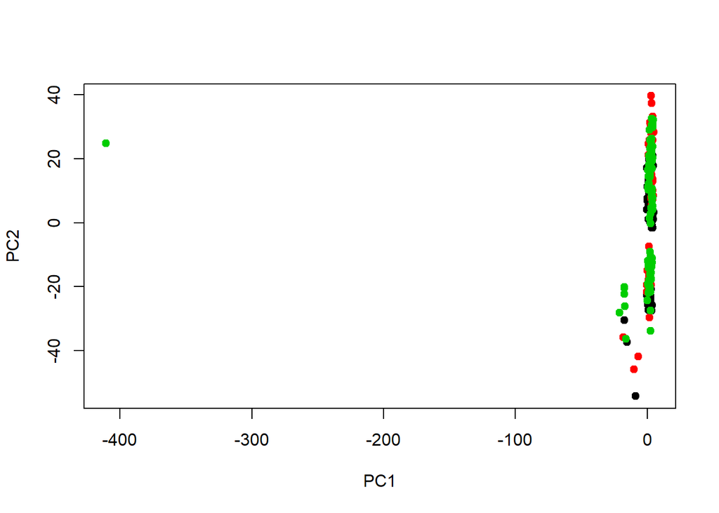

```r
#creating normalized PCA
Y1 = X1/rowSums(X1)
normpca <- stats::prcomp(Y1, scale=TRUE)
#colored by experiment
plot(normpca$x, pch=19, col=data$experiment)
```

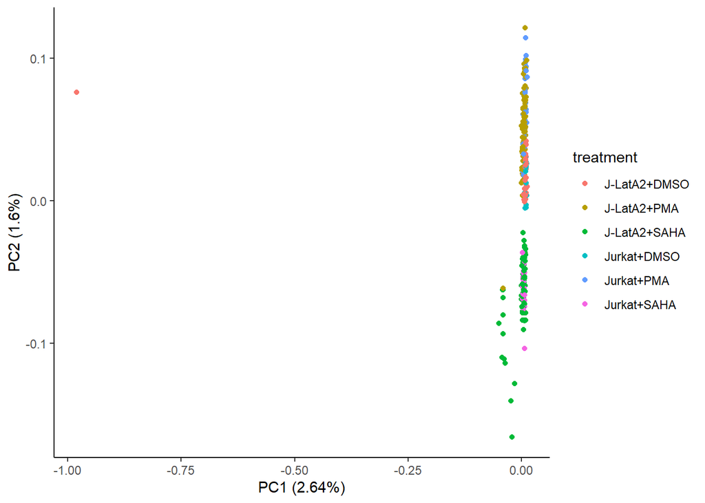

```r
#colored by treatment, using autoplot
ggplot2::autoplot(normpca, data=data, colour="treatment") + theme_classic()
```

DMSO is the control and it’s very similar to PMA, meaning that PMA doesn’t have a significant effect. On the other hand, SAHA is very different from both of them, meaning that it has a significant effect. There is no batch effect, because in the graph colored by experiment the samples are not clustered based on the experiment that they’re part of. However, we scaled the PCA and the scaled PCAs are more precise

```r
#tSNE
tsne1 <- Rtsne(X1)

## Check results generated
names(tsne1)
```

```
##  [1] "N"                   "Y"                   "costs"
##  [4] "itercosts"           "origD"               "perplexity"
##  [7] "theta"               "max_iter"            "stop_lying_iter"
## [10] "mom_switch_iter"     "momentum"            "final_momentum"
## [13] "eta"                 "exaggeration_factor"
```

```r
head(tsne1$Y)
```

```
##             [,1]      [,2]
## [1,]   0.7162566 -5.388733
## [2,] -10.9758758  1.281022
## [3,]   3.1073368 -3.587083
## [4,]  -0.2231382  3.236129
## [5,]  -2.3463918 -5.459749
## [6,]  -0.3440498 -5.775563
```

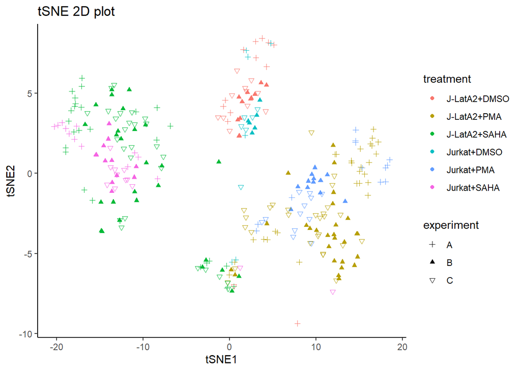

```r
tsne_data <- as.data.frame(tsne1$Y)
tsne_data$experiment <- data$experiment
tsne_data$treatment <- data$treatment

## ggplot
ggplot(tsne_data, aes(x=V1, y=V2)) +
  geom_point(aes(color=treatment, shape=experiment)) +
  scale_shape_manual(values = c(3,17, 6)) +
  ggtitle("tSNE 2D plot") + xlab("tSNE1") + ylab("tSNE2") +
  theme_classic()
```

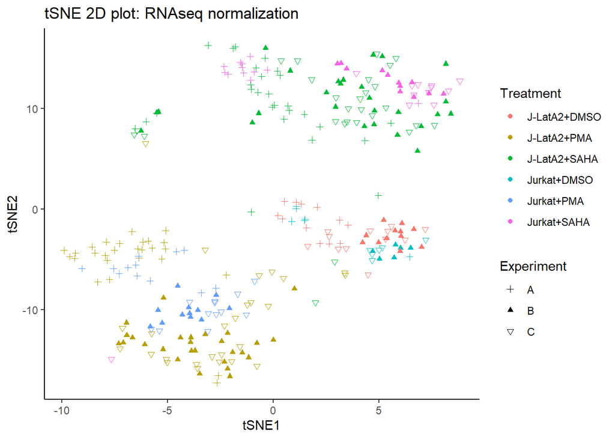

```r
## Normalized tSNE
X1=X1[, colSums(X1)>0]
Y = X1/rowSums(X1)
tSNE_norm <- Rtsne(Y, pca=TRUE)
tsne_data2 <- as.data.frame(tSNE_norm$Y)
tsne_data2$Experiment <- data$experiment
tsne_data2$Treatment <- data$treatment
## ggplot
tSNE2 <- ggplot(tsne_data2, aes(x=V1, y=V2)) +
  geom_point(aes(color=Treatment, shape=Experiment)) +
  scale_shape_manual(values = c(3,17,6)) +
  ggtitle("tSNE 2D plot: RNAseq normalization") + xlab("tSNE1") + ylab("tSNE2") + theme_classic()
print(tSNE2)
```

Question 4

```
## [1] "tSNE perplexity=1"
```

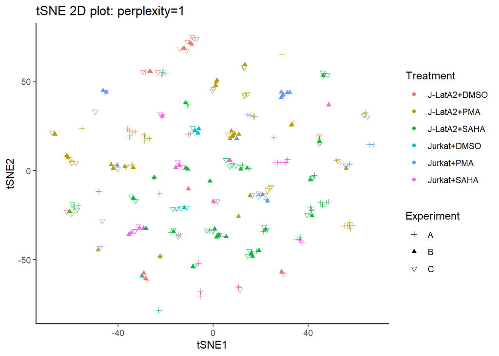

```
## [1] "tSNE perplexity=5"
```

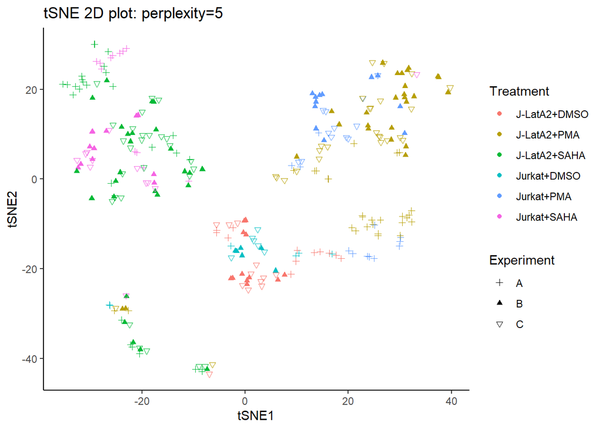

```
## [1] "tSNE perplexity=10"
```

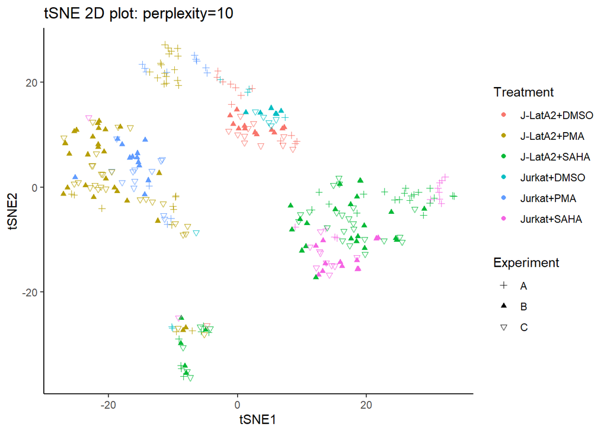

```
## [1] "tSNE perplexity=25"
```

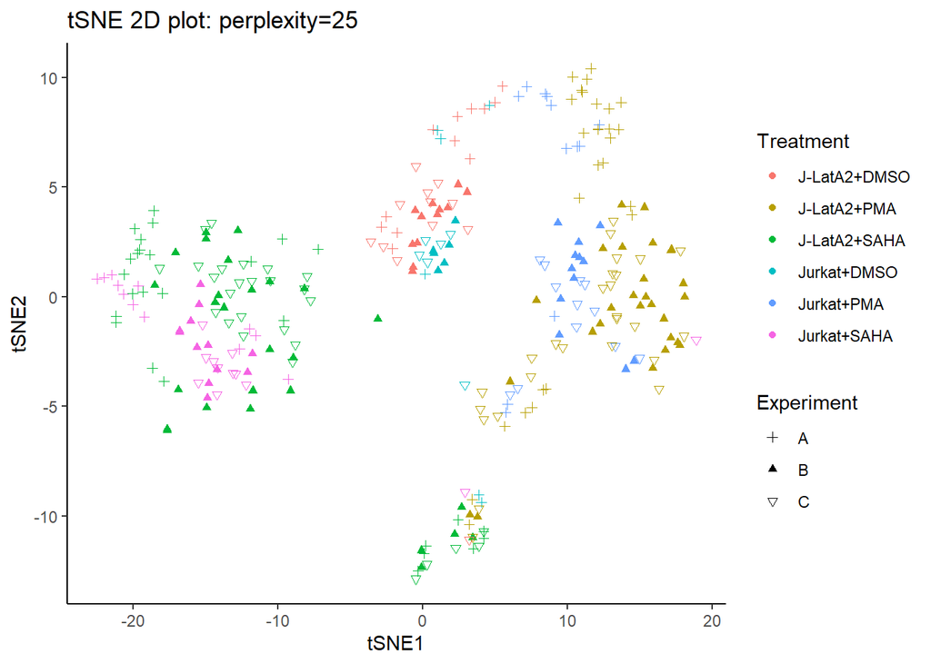

```
## [1] "tSNE perplexity=50"
```

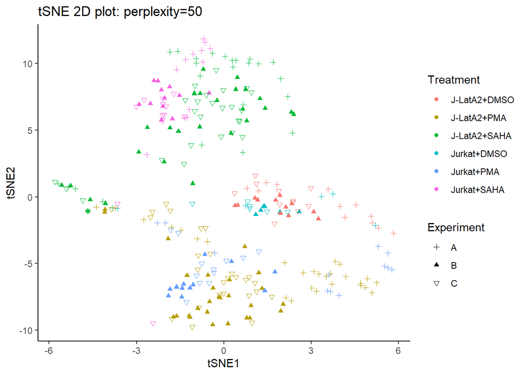

```r
#changing perplexity
set.seed(123) ## allows us to reproduce results

list_plots <- list()
for (p_value in c(1, 5, 10, 25, 50)) {
  print(paste0("tSNE perplexity=", p_value))

  ## Default parameters for Rtsne
  tsne_p <- Rtsne(X1, perplexity = p_value)

  tsne_data2 <- as.data.frame(tsne_p$Y)
  tsne_data2$Treatment <- data$treatment
  tsne_data2$Experiment <- data$experiment

  ## ggplot
  plot_p <- ggplot(tsne_data2, aes(x=V1, y=V2)) +
    geom_point(aes(color=Treatment, shape=Experiment)) +
    scale_shape_manual(values = c(3,17,6)) +
    ggtitle(paste0("tSNE 2D plot: perplexity=", p_value)) + xlab("tSNE1") + ylab("tSNE2") +
    theme_classic()

  print(plot_p)

  # alternative: save plots in list_plots
  list_plots[[paste0("perp_", p_value)]] = plot_p
}
```

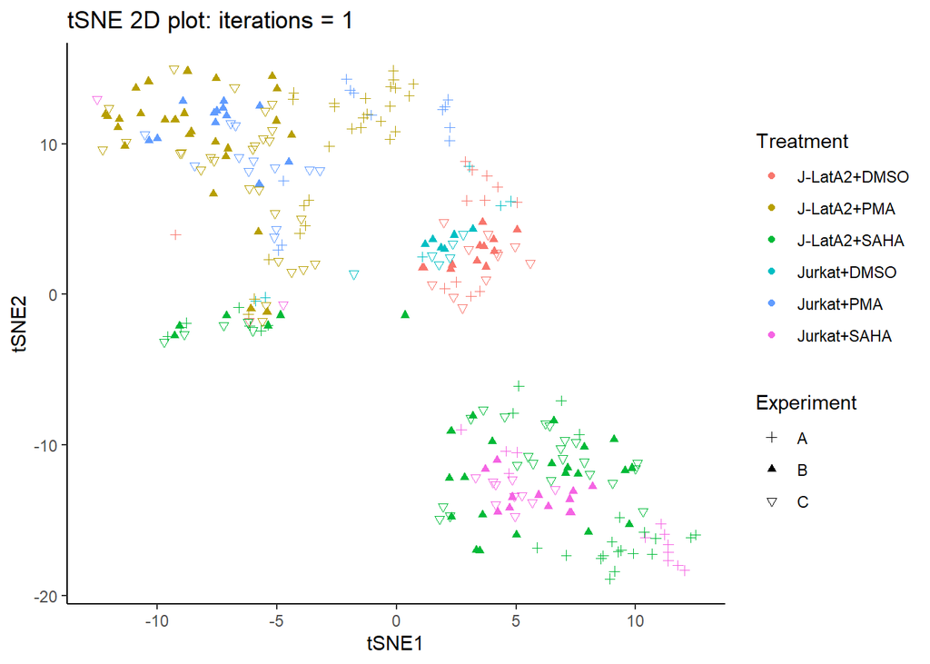

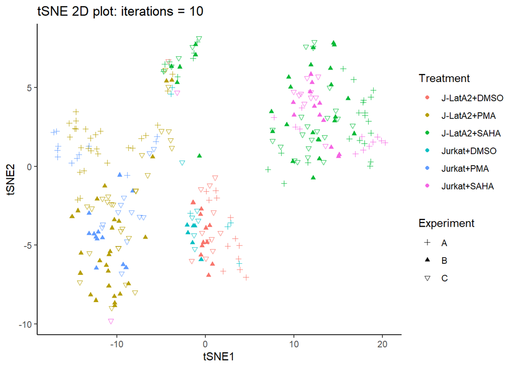

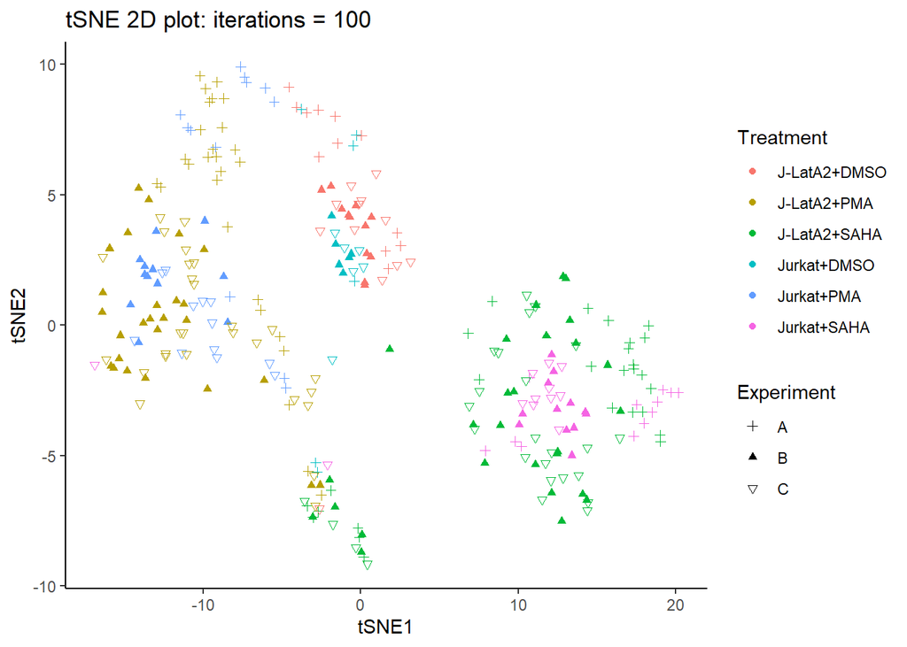

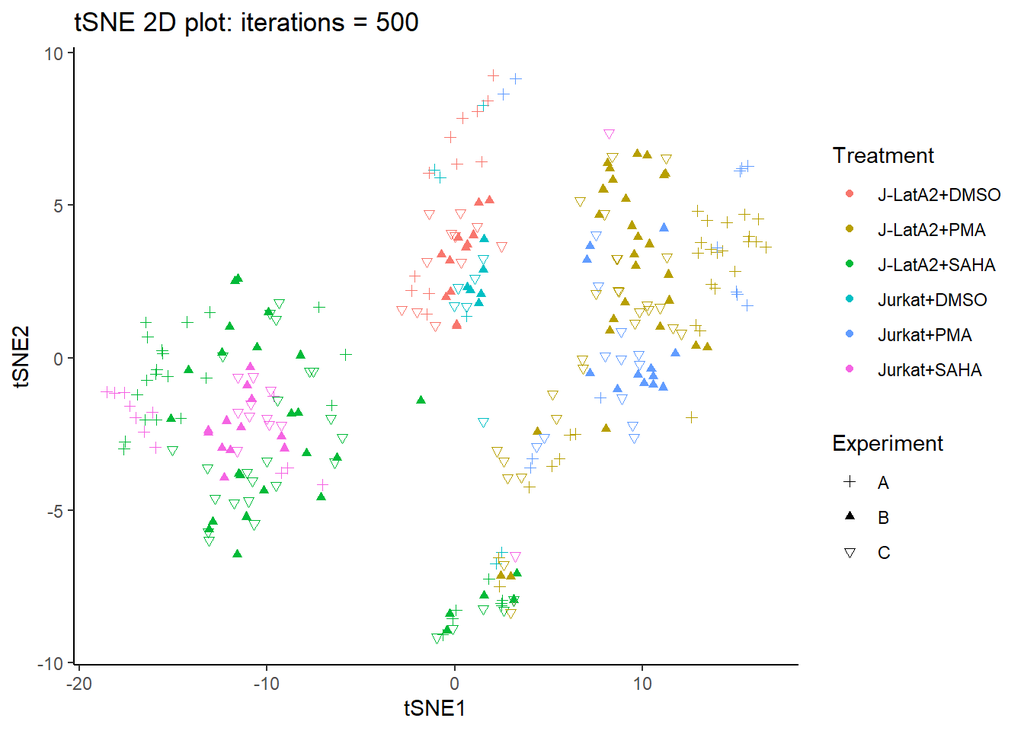

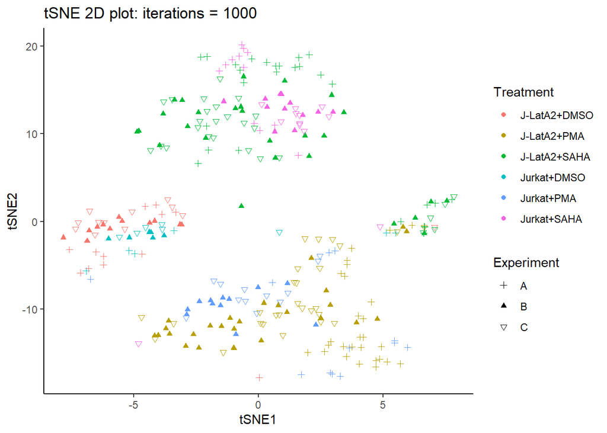

```r
#changing max_iterations
set.seed(123) ## allows us to reproduce results

for (max_iter in c(1, 10, 100, 500, 1000)) {
  tsne <- Rtsne(X1)

  tsne_data <- as.data.frame(tsne$Y)
  tsne_data$Experiment <- data$experiment
  tsne_data$Treatment <- data$treatment

  library(ggplot2)
  p <- ggplot(tsne_data, aes(x=V1, y=V2)) +
   geom_point(aes(color=Treatment, shape=Experiment)) +
   scale_shape_manual(values = c(3,17,6)) +
   ggtitle(paste("tSNE 2D plot: iterations =", max_iter)) + xlab("tSNE1") + ylab("tSNE2") +
   theme_classic()
  print(p)
}
```

QUESTION 5

No, it is pretty clear from both the PCA and the tSNE graphs that SAHA and PMA have a different effect on the cells as the points associated to each drug are grouped very distinctly in two separate clusters. In particular, from the PCA plot we see that PMA treated cells are observed to be closer in similarity to DMSO (control) cells, so we might assume that PMA has a smaller effect than SAHA.

QUESTION 6

The PC1 separates dead from alive cells, meanwhile PC2 separates differently tretated cells. On the right we have cells with low expression of genes, on the left with high expression.